# Bellabeat Analysis

Tim R

03/01/2022

$~$

## Introduction

$~$

### Business Task

In this case study I am going to analyze fitbit user data to to find ways in which bellabeat can improve its product offerings and increase usage

$~$

### What is bellabeat

Bellabeat is women focused fitness company which offers a variety of products to improve their overall health.

$~$

## Process

I will be using R studio for the whole data analysis process as R is more suikted for analyzing big amounts of data compared to excel and offers the opportunity to create visualizations

$~$

The packages I will be using can be found in tidyverse namely * ggplot 2 for visualizations * readr for importing and reading the csv data sets

$~$

### Data intergrity

- The data is trustworthy because it is licensed by the CCO public domain
- The negatives however are that the sample group consists only of 30 participants and individual gender is is not revealed

$~$

### Prepare

$~$

### Intstall Packages and datasets

#### Firstly we need to install our r packages and load them, weven if we were coding on a script and transferred our code to markdown, we still need to redo the process as `R tends to treat them as two different sessions

```
##
##  /var/folders/12/dmr0_94d07q01v4t7thw_m880000gn/T//Rtmp0ByBHh/downloaded_packages
```

$~$

### Processing and analyzing data

##### We want to make sure that our data has been loaded correctly so it is important to get a glimpse of its layout and compare the different data frames for similarities like identical column names etc.To do that I will use the heead function.

#### Daily activity

```
## # A tibble: 6 × 15
##        Id ActivityDate TotalSteps TotalDistance TrackerDistance LoggedActivitie…
##     <dbl> <chr>             <dbl>         <dbl>           <dbl>            <dbl>
## 1  1.50e9 4/12/2016         13162          8.5             8.5                 0
## 2  1.50e9 4/13/2016         10735          6.97            6.97                0
## 3  1.50e9 4/14/2016         10460          6.74            6.74                0
## 4  1.50e9 4/15/2016          9762          6.28            6.28                0
## 5  1.50e9 4/16/2016         12669          8.16            8.16                0
## 6  1.50e9 4/17/2016          9705          6.48            6.48                0
## # … with 9 more variables: VeryActiveDistance <dbl>,
## #   ModeratelyActiveDistance <dbl>, LightActiveDistance <dbl>,
## #   SedentaryActiveDistance <dbl>, VeryActiveMinutes <dbl>,
## #   FairlyActiveMinutes <dbl>, LightlyActiveMinutes <dbl>,
## #   SedentaryMinutes <dbl>, Calories <dbl>
```

$~$

#### Heart rate

```
## # A tibble: 6 × 3
##           Id Time                 Value
##        <dbl> <chr>                <dbl>
## 1 2022484408 4/12/2016 7:21:00 AM    97
## 2 2022484408 4/12/2016 7:21:05 AM   102
## 3 2022484408 4/12/2016 7:21:10 AM   105
## 4 2022484408 4/12/2016 7:21:20 AM   103
## 5 2022484408 4/12/2016 7:21:25 AM   101
## 6 2022484408 4/12/2016 7:22:05 AM    95
```

$~$

#### Weightlog

```
## # A tibble: 6 × 8
##           Id Date      WeightKg WeightPounds   Fat   BMI IsManualReport    LogId
##        <dbl> <chr>        <dbl>        <dbl> <dbl> <dbl> <lgl>             <dbl>
## 1 1503960366 5/2/2016…     52.6         116.    22  22.6 TRUE            1.46e12
## 2 1503960366 5/3/2016…     52.6         116.    NA  22.6 TRUE            1.46e12
## 3 1927972279 4/13/201…    134.          294.    NA  47.5 FALSE           1.46e12
## 4 2873212765 4/21/201…     56.7         125.    NA  21.5 TRUE            1.46e12
## 5 2873212765 5/12/201…     57.3         126.    NA  21.7 TRUE            1.46e12
## 6 4319703577 4/17/201…     72.4         160.    25  27.5 TRUE            1.46e12
```

$~$

#### Amount of sleep in a day

```
## # A tibble: 6 × 5
##           Id SleepDay          TotalSleepRecor… TotalMinutesAsle… TotalTimeInBed
##        <dbl> <chr>                        <dbl>             <dbl>          <dbl>
## 1 1503960366 4/12/2016 12:00:…                1               327            346
## 2 1503960366 4/13/2016 12:00:…                2               384            407
## 3 1503960366 4/15/2016 12:00:…                1               412            442
## 4 1503960366 4/16/2016 12:00:…                2               340            367
## 5 1503960366 4/17/2016 12:00:…                1               700            712
## 6 1503960366 4/19/2016 12:00:…                1               304            320
```

$~$

### Summarised Data

##### Once that is done we now get into a deeper analysis and this is where the summary function comes into play as it gives us a rundown of each data frame, which saves us time and the need to compute complex mathematical equations manually. Through the use of the head and summary function we can clearly see that all these data frames have a common ID column which we will later use in this analysis for merging data frames.

$~$

#### Daily Activity

```
##        Id            ActivityDate         TotalSteps    TotalDistance
##  Min.   :1.504e+09   Length:940         Min.   :    0   Min.   : 0.000
##  1st Qu.:2.320e+09   Class :character   1st Qu.: 3790   1st Qu.: 2.620
##  Median :4.445e+09   Mode  :character   Median : 7406   Median : 5.245
##  Mean   :4.855e+09                      Mean   : 7638   Mean   : 5.490
##  3rd Qu.:6.962e+09                      3rd Qu.:10727   3rd Qu.: 7.713
##  Max.   :8.878e+09                      Max.   :36019   Max.   :28.030
##  TrackerDistance  LoggedActivitiesDistance VeryActiveDistance
##  Min.   : 0.000   Min.   :0.0000           Min.   : 0.000
##  1st Qu.: 2.620   1st Qu.:0.0000           1st Qu.: 0.000
##  Median : 5.245   Median :0.0000           Median : 0.210
##  Mean   : 5.475   Mean   :0.1082           Mean   : 1.503
##  3rd Qu.: 7.710   3rd Qu.:0.0000           3rd Qu.: 2.053
##  Max.   :28.030   Max.   :4.9421           Max.   :21.920
##  ModeratelyActiveDistance LightActiveDistance SedentaryActiveDistance
##  Min.   :0.0000           Min.   : 0.000      Min.   :0.000000
##  1st Qu.:0.0000           1st Qu.: 1.945      1st Qu.:0.000000
##  Median :0.2400           Median : 3.365      Median :0.000000
##  Mean   :0.5675           Mean   : 3.341      Mean   :0.001606
##  3rd Qu.:0.8000           3rd Qu.: 4.782      3rd Qu.:0.000000
##  Max.   :6.4800           Max.   :10.710      Max.   :0.110000
##  VeryActiveMinutes FairlyActiveMinutes LightlyActiveMinutes SedentaryMinutes
##  Min.   :  0.00    Min.   :  0.00      Min.   :  0.0        Min.   :   0.0
##  1st Qu.:  0.00    1st Qu.:  0.00      1st Qu.:127.0        1st Qu.: 729.8
##  Median :  4.00    Median :  6.00      Median :199.0        Median :1057.5
##  Mean   : 21.16    Mean   : 13.56      Mean   :192.8        Mean   : 991.2
##  3rd Qu.: 32.00    3rd Qu.: 19.00      3rd Qu.:264.0        3rd Qu.:1229.5
##  Max.   :210.00    Max.   :143.00      Max.   :518.0        Max.   :1440.0
##     Calories
##  Min.   :   0
##  1st Qu.:1828
##  Median :2134
##  Mean   :2304
##  3rd Qu.:2793
##  Max.   :4900
```

$~$

#### Heart rate

```
##        Id                Time               Value
##  Min.   :2.022e+09   Length:2483658     Min.   : 36.00
##  1st Qu.:4.388e+09   Class :character   1st Qu.: 63.00
##  Median :5.554e+09   Mode  :character   Median : 73.00
##  Mean   :5.514e+09                      Mean   : 77.33
##  3rd Qu.:6.962e+09                      3rd Qu.: 88.00
##  Max.   :8.878e+09                      Max.   :203.00
```

##### The average heartrate is 77 which falls right in between the desired 50-80 men and 53-83 for women which at a glance would mean that on average our sample group has a healthy heart rate however it is important to note that it is normal for the heartrate to go beyond these boundaries as many triggers can prompt it to either beat faster than normal or much slower such as sudden shock our trauma therefore more analysis would be needed here.

$~$

#### Weightlog

```
##        Id                Date              WeightKg       WeightPounds
##  Min.   :1.504e+09   Length:67          Min.   : 52.60   Min.   :116.0
##  1st Qu.:6.962e+09   Class :character   1st Qu.: 61.40   1st Qu.:135.4
##  Median :6.962e+09   Mode  :character   Median : 62.50   Median :137.8
##  Mean   :7.009e+09                      Mean   : 72.04   Mean   :158.8
##  3rd Qu.:8.878e+09                      3rd Qu.: 85.05   3rd Qu.:187.5
##  Max.   :8.878e+09                      Max.   :133.50   Max.   :294.3
##
##       Fat             BMI        IsManualReport      LogId
##  Min.   :22.00   Min.   :21.45   Mode :logical   Min.   :1.460e+12
##  1st Qu.:22.75   1st Qu.:23.96   FALSE:26        1st Qu.:1.461e+12
##  Median :23.50   Median :24.39   TRUE :41        Median :1.462e+12
##  Mean   :23.50   Mean   :25.19                   Mean   :1.462e+12
##  3rd Qu.:24.25   3rd Qu.:25.56                   3rd Qu.:1.462e+12
##  Max.   :25.00   Max.   :47.54                   Max.   :1.463e+12
##  NA's   :65
```

##### For this part we will focus on the BMI which stands for body mass index, which is used to calculate whether someone is considered obese or not and the formula is BMI=kg/m2. Our average BMI is 25.19 which is considered overweight as the healthy range is 18.5 to 24.9

$~$

#### Amount of sleep in a day

```
##        Id              SleepDay         TotalSleepRecords TotalMinutesAsleep
##  Min.   :1.504e+09   Length:413         Min.   :1.000     Min.   : 58.0
##  1st Qu.:3.977e+09   Class :character   1st Qu.:1.000     1st Qu.:361.0
##  Median :4.703e+09   Mode  :character   Median :1.000     Median :433.0
##  Mean   :5.001e+09                      Mean   :1.119     Mean   :419.5
##  3rd Qu.:6.962e+09                      3rd Qu.:1.000     3rd Qu.:490.0
##  Max.   :8.792e+09                      Max.   :3.000     Max.   :796.0
##  TotalTimeInBed
##  Min.   : 61.0
##  1st Qu.:403.0
##  Median :463.0
##  Mean   :458.6
##  3rd Qu.:526.0
##  Max.   :961.0
```

$~$

### Sharing

$~$

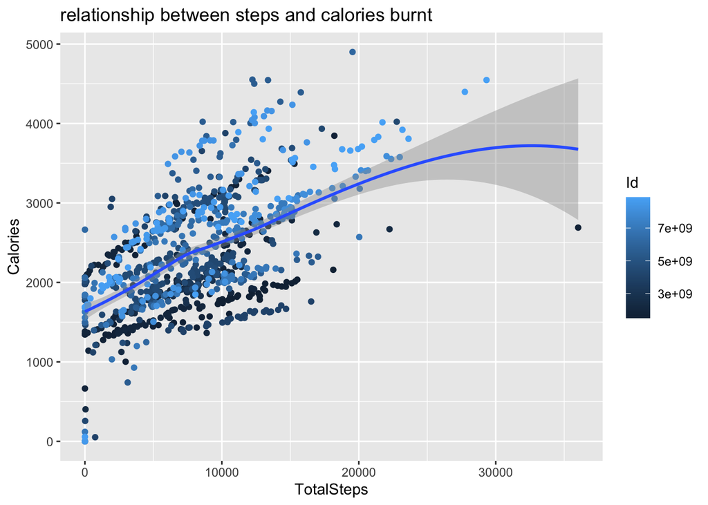

We can tell that there is a positive correlation between walking and calories burnt, and this should useful; in encouraging people to spend as much time as they can moving in order to maintain a healthy body

$~$

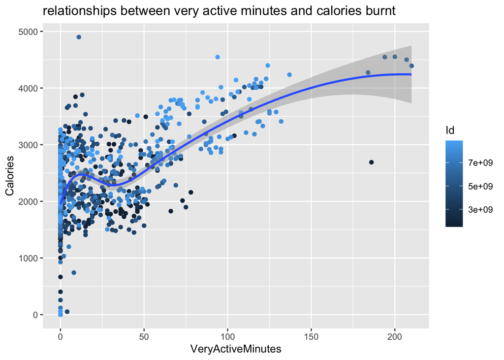

Just like the amount of steps taken there is a positive correlation between time spent exercising and the amount iof calories burnt during the process

$~$

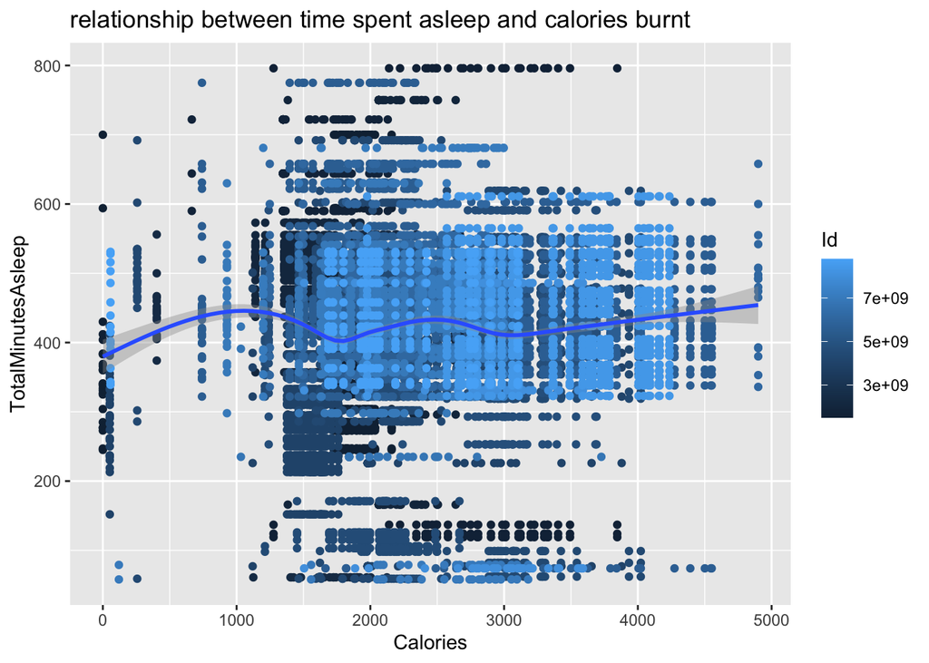

The correlation between amount of sleep taken and calories burnt in according to this graph seems to be nonexistent which could mean that other factors are more important for that like diet and exercise

$~$

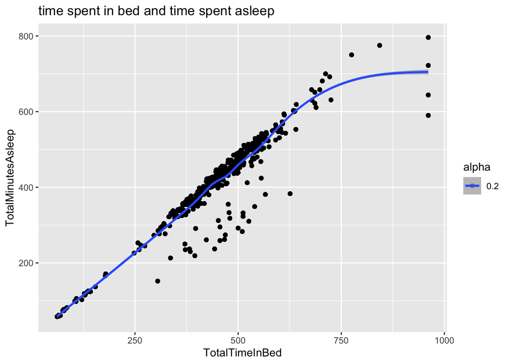

Here we can tell that the more time somones spends in bed the more time they spend sleeping

$~$

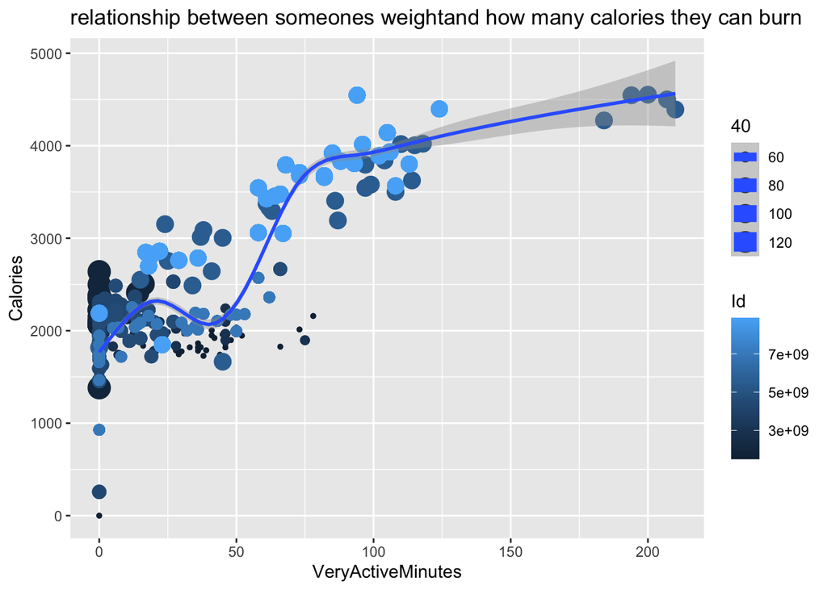

```r
dawl<-merge(da,wl, by="Id")
ggplot(data=dawl)+geom_point(mapping = aes(x=VeryActiveMinutes,y=Calories,colour=Id, size=WeightKg))+ geom_smooth(mapping = aes(x=VeryActiveMinutes,y=Calories, colour=Id, size=WeightKg))+ labs(title = "relationship between someones weightand how many calories they can burn", size=40)
```

This graph shows us that the more someones weighs the more calories they burn per activity compared to people who weigh less than them, this is because a calorie is a unit of energy and the more someone weighs the more energy is required to move their body

$~$

## Act

$~$

### Recommendations

- By analyzing how users of other competitors products are using them we can see how and where to improve our current offering, one recommendation I would suggest is including an accountability feature in the app, this can be in the form of AI to help push the users to helps reach their daily goals, this would especially helpful in insuring that the users get the needed 10 000 steps a day.
- Another recommendation to improve sleep efficiency is to include a sleep tracker that tells users how well they are sleeping and how to improve sleep quality, a good way to do this would be a tracker that offers users graphical representation of their sleep patterns
- Since it is during a pandemic and gyms are closed in some areas in might be important to introduce virtual training sessions to insure that even if people are stuck at home they are still able to maintain a healthy lifestyle and stay motivated.
- These classes are also important in creating a fun workout environment which is less draining during winter seasons as users dont need to step out into the cold to exercise

$~$